# Third Week: Exploratory Data Analysis

LaLiga Analysis

Kimia Hamidieh (95109434)

# تمرین سری سوم: از لالیگا تا لیگ برتر

> با استفاده از داده های لیگ دسته اول اسپانیا به سوالات زیر پاسخ دهید. از هر دو ابزار ggplot2 و highcharter برای این کار تصویرسازی استفاده نمایید.

در ابتدا جدول لیگ را برای هریک از تیم ها می سازیم. همچنین جدولی از وضعیت تیم ها در هر تاریخ و وضعیت بازی انجام شده در آن تاریخ را می سازیم تا در قسمت های بعد کارمان راحت تر شود.

```r
data(package="engsoccerdata")
laliga = as.tbl(spain)

rbind(
  laliga %>%
    select(Date, Season, team = home, opp = visitor, GF = hgoal, GA = vgoal),
  laliga %>%
    select(Date, Season, team = visitor, opp = home, GF = vgoal, GA = hgoal)
) %>%
  mutate(GD = GF - GA, score = (GD > 0) * 3 + (GD == 0)) -> games

games %>%
  select(Season, team) %>%
  group_by(Season) %>%
  distinct() %>%
  summarise(n = n()) %>%
  spread(key = Season, value = n) %>%
  as.vector() -> teams_number

head(games)
```

```
## # A tibble: 6 x 8
##   Date       Season team               opp            GF    GA    GD score
##   <date>      <dbl> <chr>              <chr>       <int> <int> <int> <dbl>
## 1 1929-02-10   1928 Arenas de Getxo    Atletico M…     2     3    -1  0
## 2 1929-02-10   1928 Espanyol Barcelona Real Union      3     2     1  3.00
## 3 1929-02-10   1928 Real Madrid        CE Europa       5     0     5  3.00
## 4 1929-02-10   1928 Real Sociedad      Athletic B…     1     1     0  1.00
## 5 1929-02-12   1928 Racing Santander   FC Barcelo…     0     2    -2  0
## 6 1929-02-17   1928 FC Barcelona       Real Madrid     1     2    -1  0
```

```r
# GD
games %>%
  select(Season, Date, team, GD) %>%
  spread(team, GD, fill = 0) -> GD_table
GD_table %>%
  gather(key = "team", value = "GD", colnames(.)[3:ncol(.)]) %>%
  arrange(Date) -> GD_df
GD_df %>%
  group_by(Season, team) %>%
  mutate(total_GD = cumsum(GD)) %>%
  arrange(team, Season, Date) -> GD_df
# total score (and gained score of Date)
games %>%
  select(Season, Date, team, score) %>%
  spread(team, score, fill = 0) -> score_table
score_table %>%
  gather(key = "team", value = "score", colnames(.)[3:ncol(.)]) %>%
  arrange(Date) -> score_df
score_df %>%
  group_by(Season, team) %>%
  mutate(total_score = cumsum(score)) %>% # total socre
  arrange(team, Season, Date) -> score_df
# number of matches (and if the game had any matches on that day)
games %>%
  select(Season, Date, team) %>%
  mutate(played = 1) %>%
  spread(team, played, fill = 0) -> matches_table
matches_table %>%
  gather(key = "team", value = "team_games", colnames(.)[3:ncol(.)]) %>%
  arrange(Date) -> matches_df
matches_df %>%
  group_by(Season, team) %>%
  mutate(matches_no = cumsum(team_games)) -> matches_df

games_df = full_join(full_join(score_df, GD_df), matches_df)

games_df %>%
  group_by(Season, Date) %>%
  mutate(rank = as.integer(rank(-total_score, -total_GD, ties.method = 'first'))) %>%
  arrange(Season, Date, rank) -> games_df
head(games_df)
```

```
## # A tibble: 6 x 10
## # Groups:   Season, Date [1]
##   Season Date       team       score total_score    GD total_GD team_games
##    <dbl> <date>     <chr>      <dbl>       <dbl> <dbl>    <dbl>      <dbl>
## 1   1928 1929-02-10 Atletico …  3.00        3.00  1.00     1.00       1.00
## 2   1928 1929-02-10 Espanyol …  3.00        3.00  1.00     1.00       1.00
## 3   1928 1929-02-10 Real Madr…  3.00        3.00  5.00     5.00       1.00
## 4   1928 1929-02-10 Athletic …  1.00        1.00  0        0          1.00
## 5   1928 1929-02-10 Real Soci…  1.00        1.00  0        0          1.00
## 6   1928 1929-02-10 AD Almeria  0           0     0        0          0
## # ... with 2 more variables: matches_no <dbl>, rank <int>
```

۱. تعداد قهرمانی های تیم ها در تاریخ لالیگا را استخراج کرده و نمودار ستونی آنها را رسم کنید.

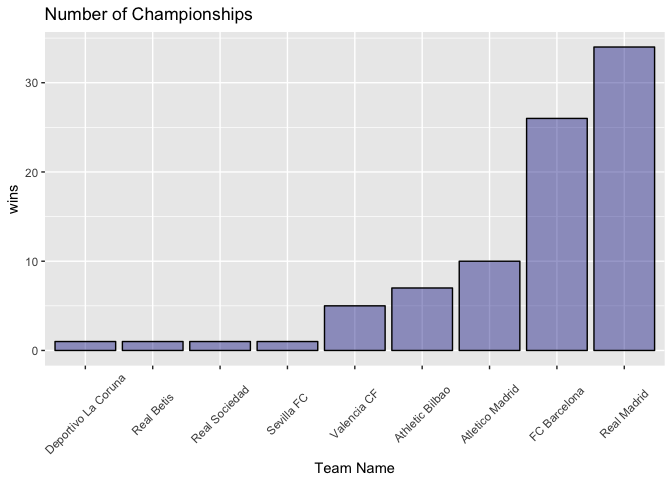

```r
games %>%
  group_by(team, Season) %>%
  summarise(score = sum(GD == 0) + sum(GD > 0) * 3) %>%
  group_by(Season) %>%
  slice(which.max(score)) %>%
  group_by(team) %>%
  summarise(wins = n()) %>%
  arrange(wins) -> winners
ggplot(data = winners, mapping = aes(x = reorder(team, wins), y = wins)) +
  geom_bar(stat = "identity", color = "black", fill = "dark blue", alpha  = 0.4) + xlab("Team Name") +
  ggtitle("Number of Championships") +
  theme(axis.text.x=element_text(angle=45, vjust=0.5))
```

```r
hchart(winners, "column", hcaes(x = team, y = wins)) %>%
  hc_add_theme(hc_theme_ffx())
```

[interactive chart not shown]

۲. کسل کننده ترین لیگ و تیم را بیابید. نمودار ده تیم و ده فصل کسل کننده را رسم کنید.

```r
laliga %>%
  group_by(Season) %>%
  summarise(goals = sum(vgoal + hgoal), games = n()) %>%
  mutate(boringness = goals / games) %>%
  arrange(boringness) %>%
  slice(1:10) -> boring_seasons
boring_seasons %>%
  kable("markdown")
```

| Season | goals | games | boringness |
| --- | --- | --- | --- |
| 1972 | 656 | 306 | 2.143791 |
| 1990 | 822 | 380 | 2.163158 |
| 1984 | 662 | 306 | 2.163399 |
| 1971 | 675 | 306 | 2.205882 |
| 1970 | 543 | 240 | 2.262500 |
| 1988 | 868 | 380 | 2.284210 |
| 1973 | 710 | 306 | 2.320261 |
| 1968 | 561 | 240 | 2.337500 |
| 1969 | 567 | 240 | 2.362500 |
| 1987 | 909 | 380 | 2.392105 |

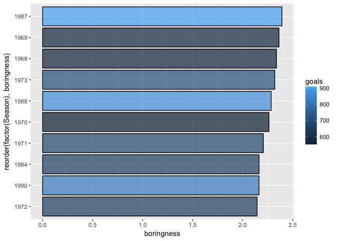

```r
ggplot(boring_seasons, aes(x = reorder(factor(Season), boringness), y = boringness, fill = goals)) +
  geom_bar(stat = "identity", color = "black", alpha  = 0.7) + coord_flip()
```

```r
hchart(boring_seasons, "bar", hcaes(x = factor(Season), y = boringness)) %>%
  hc_add_theme(hc_theme_ffx())
```

[interactive chart not shown]

```r
games %>%
  group_by(team) %>%
  summarise(totaleqs = sum(GD == 0) , games = n()) %>%
  mutate(boringness = totaleqs / games) %>%
  arrange(boringness) %>%
  slice(1:10) -> boring_teams
boring_teams %>%
  kable("markdown")
```

| team | totaleqs | games | boringness |
| --- | --- | --- | --- |
| CE Europa | 6 | 54 | 0.1111111 |
| CD Leonesa | 4 | 30 | 0.1333333 |
| Gimnastic | 16 | 116 | 0.1379310 |
| Real Jaen | 13 | 90 | 0.1444444 |
| CD Alcoyano | 16 | 108 | 0.1481481 |
| Arenas de Getxo | 21 | 130 | 0.1615385 |
| Atletico Tetuan | 5 | 30 | 0.1666667 |
| Real Union | 14 | 72 | 0.1944444 |
| Real Madrid | 552 | 2762 | 0.1998552 |
| FC Barcelona | 560 | 2762 | 0.2027516 |

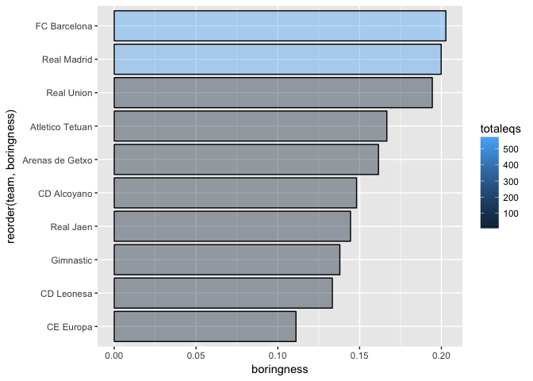

```r
ggplot(boring_teams, aes(x = reorder(team, boringness), y = boringness, fill = totaleqs)) +
  geom_bar(stat = "identity", color = "black", alpha  = 0.4) + coord_flip()
```

```r
hchart(boring_teams, "bar", hcaes(x = factor(team), y = boringness)) %>%
  hc_add_theme(hc_theme_ffx())
```

[interactive chart not shown]

۳. در چند درصد موارد قهرمان نیم فصل در پایان فصل قهرمان شده است؟

نیم فصل معادل جایی است که هر دو تیم یک بار باهم بازی کرده اند. بنابراین یکبار بازی اول بین هر دو تیم را جدا کرده و یکبار هم در کل قهرمان را به دست می آوریم.

```r
games %>%
  arrange(Season, team, opp) %>%
  filter(as.integer(rownames(.)) %% 2 == 1) %>%
  group_by(Season, team) %>%
  summarise(points = sum(score))  %>%
  group_by(Season) %>%
  slice(which.max(points)) -> first_half_games

games %>%
  arrange(Season, team, opp) %>%
  group_by(Season, team) %>%
  summarise(points = sum(score))  %>%
  group_by(Season) %>%
  slice(which.max(points)) -> all_games

eq_percent = length(which(first_half_games$team == all_games$team)) / length(all_games$team)
print(eq_percent)
```

```
## [1] 0.5813953
```

۴. در بین سال های ۲۰۰۱ تا ۲۰۱۰ گربه سیاه تیم های بزرگ چه تیم هایی بوده است؟

```r
blackcats = NULL
for(s in 2001:2012) {
  games_df %>%
    filter(Season == as.integer(s)) %>%
    group_by(team) %>%
    filter(max(matches_no) != 0) %>%
    filter(matches_no == max(matches_no)) %>%
    group_by() %>%
    arrange(rank) %>%
    select(team, total_score, total_GD, rank) -> season_ranking
  season_ranking %>% filter(rank < 5) %>% select(team) %>% unique() -> big_teams
  season_ranking %>% filter(nrow(.) - rank < 3 / 4 * nrow(.)) -> ord_teams
  rbind(
  games %>%
    filter(Season == as.integer(s)) %>%
    filter(team %in% ord_teams$team) %>%
    group_by() %>%
    filter(score == 3 & opp %in% big_teams$team) %>%
    filter(GD == max(GD)) %>%
    mutate(blackcat = team) %>%
    select(Season, blackcat, opp, GD), blackcats) -> blackcats
}
kable(blackcats, "html")
```

| Season | blackcat | opp | GD |
| --- | --- | --- | --- |
| 2012 | Athletic Bilbao | Atletico Madrid | 3 |
| 2011 | Espanyol Barcelona | Valencia CF | 4 |
| 2010 | Real Zaragoza | Valencia CF | 4 |
| 2009 | Atletico Madrid | Valencia CF | 3 |
| 2009 | Real Zaragoza | Valencia CF | 3 |
| 2008 | Racing Santander | Atletico Madrid | 4 |
| 2007 | Real Zaragoza | Villarreal CF | 3 |
| 2007 | Espanyol Barcelona | Villarreal CF | 3 |
| 2006 | Getafe CF | Valencia CF | 3 |
| 2006 | Recreativo Huelva | Real Madrid | 3 |
| 2005 | Real Betis | CA Osasuna | 2 |
| 2004 | Deportivo La Coruna | Real Madrid | 2 |
| 2004 | Deportivo La Coruna | Villarreal CF | 2 |
| 2004 | Atletico Madrid | FC Barcelona | 2 |
| 2004 | Athletic Bilbao | Real Madrid | 2 |
| 2003 | Malaga CF | FC Barcelona | 4 |
| 2002 | Villarreal CF | Celta Vigo | 5 |
| 2001 | RCD Mallorca | Deportivo La Coruna | 3 |
| 2001 | Real Valladolid | Deportivo La Coruna | 3 |
| 2001 | Real Sociedad | Real Madrid | 3 |

۵. در تاریخ لالیگا کدام تیم رکورددار زودترین قهرمانی است؟ همچنین کدام تیم مقتدرانه ترین قهرمانی را داشته است؟

```r
games_df %>%
  mutate(n = as.integer(teams_number[as.character(Season)])) %>%
  filter(matches_no != 0) %>%
  filter(rank == 1 | rank == 2) %>%
  mutate(score_dif = max(total_score) - min(total_score)) %>%
  filter(rank == 1) %>%
  mutate(games_left = 2 * (n - 2) - matches_no) %>%
  mutate(championship = score_dif / games_left) %>%
  arrange(Season, Date) -> seasons_winners

# early winner
seasons_winners %>%
  group_by() %>%
  filter(championship > 3) %>%
  slice(which.max(games_left)) %>%
  select(Season, Date, team, total_score, total_GD, games_left, score_dif) %>%
  kable("markdown")
```

| Season | Date | team | total_score | total_GD | games_left | score_dif |
| --- | --- | --- | --- | --- | --- | --- |
| 1960 | 1961-02-26 | Real Madrid | 62 | 57 | 5 | 18 |

```r
seasons_winners %>%
  group_by() %>%
  filter(games_left > 0) %>%
  slice(which.max(championship)) %>%
  select(Season, Date, team, total_score, total_GD, games_left, score_dif) %>%
  kable("markdown")
```

| Season | Date | team | total_score | total_GD | games_left | score_dif |
| --- | --- | --- | --- | --- | --- | --- |
| 1960 | 1961-03-26 | Real Madrid | 72 | 62 | 1 | 19 |

۶. طولانی ترین نوار پیروزی مساوی و شکست مال چه تیم هایی است؟

```r
# longest contigous wins
games_df %>%
  group_by(Season, team) %>%
  filter(team_games == 1) %>%
  arrange(Season, team, Date) %>%
  mutate(won = as.integer(score == 3)) %>%
  mutate(seq_no = sequence(rle(won)$lengths)) %>%
  group_by() %>%
  slice(which.max(won * seq_no)) %>%
  select(Season, Date, team, seq_no, matches_no, total_score, total_GD) %>%
  kable("markdown")
```

| Season | Date | team | seq_no | matches_no | total_score | total_GD |
| --- | --- | --- | --- | --- | --- | --- |
| 2010 | 2011-02-05 | FC Barcelona | 16 | 22 | 61 | 59 |